# Practical Considerations

Pietro Franceschi | pietro.franceschi@fmach.it

## The starting point

Start from a clear question

## First things first

- What is the best strategy to quench metabolism?
- What is the best way to extract my samples?
- What is the best way to store my samples?
- **MS performance degrades with time**: how long can I run my sample list before cleaning

## Controlling analytical variability

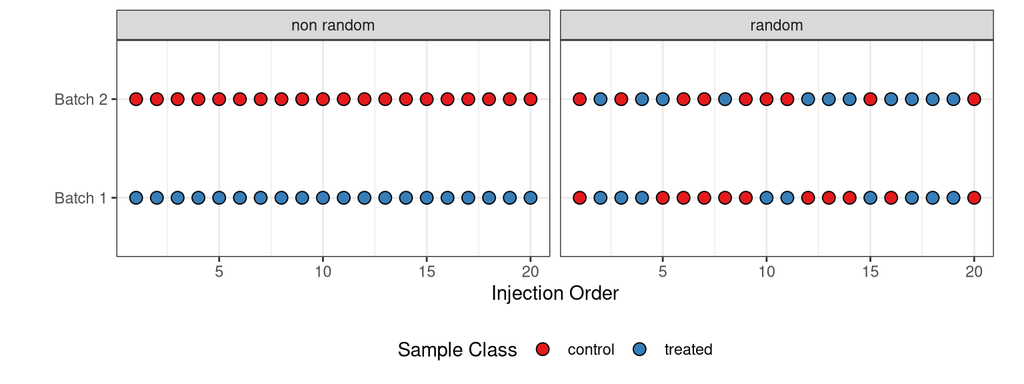

- **Block** your experimental design on the analytical batch
- Reduce as much as possible the length of the chromatographic run
- **Measure the analytical variability**

## Your silver bullet: Quality Control Samples (QC)

- Reference samples which are regularly injected along the sequence.
- They measure analytical stability because the sample itself is the same.
- QC samples should be representative of the chemical complexity of the samples
- **Pooled samples** are often the preferred choice

## A fairly good sample list

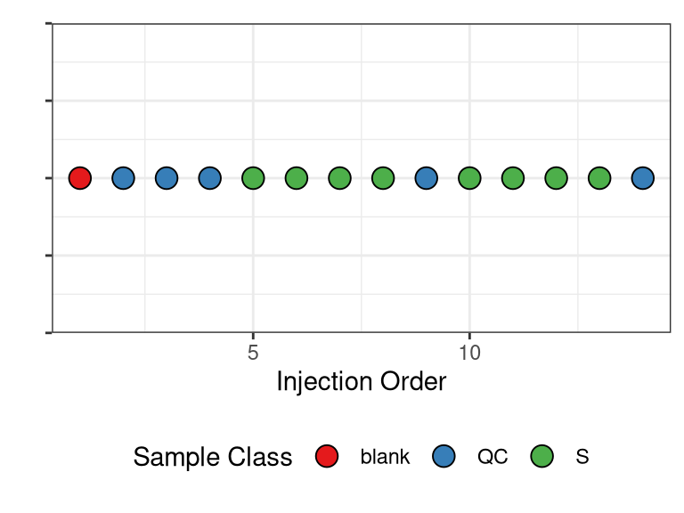

- The usefulness of blanks is disputed
- The first repeated QCs are used to allow the column to equilibrate
- One could add QC dilutions
- Also the design of the sequence can be validated

## Other relevant points of discussion

- Standards and blanks
- Analytical batches and batch effect
- Randomization, analytical batches and large studies in clinical settings

## DDA and Fragmentation

[figure not shown]

Experiments combining full scan and fragmentation are quite popular, because fragmentation patterns are needed for metabolite annotation and for setting up quantitative methods

## Use your time wisely

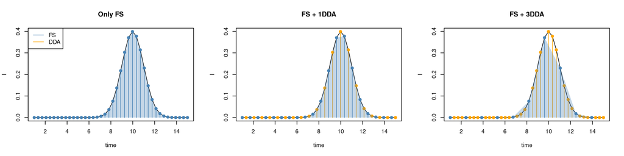

The more experiments I do, the worse my estimate of the peak area …

- plan different runs for FS and DDA
- fragment only ions of interest
- strike a balance between chromatography, instrument speed and number of experiments